# `(prep -> plot -> print)`: Technique for Reproducible Graphing

Andriy Koval

Date: 2019-06-12

# overview

This document narrates the demonstration of the `(prep + plot + print) + place` technique using the data from VADA 2019 Summer School Data Challenge. See github.com/andkov/vada-2019-summer-school repository for reproducible scripts.

A fully reproducible example of the same technique using publically available data from the Canadian Chronic Disease Surveillance System (CCDSS) is featured at [`github.com/dss-ialh/graph-making-scenarios`](https://github.com/dss-ialh/graph-making-scenarios/blob/master/README.md) (see Scenario 3).

The technique for reproducible graphing demonstrated here procedes in the following sequence of phases:

- PHASE 0 - explore the data
- PHASE 1 - build the graph
- PHASE 2 - compose `plot` function
- PHASE 3 - split into `prep` and `plot` functions
- PHASE 4 - add the `print` function
- PHASE 5 - serialize graph production
- PHASE 6 - `place` graphs onto canvas

## disclaimer

- This essay is more about making graphs than about analyzing data
- This essay is more about demonstrating a technique than about prescribing a framework.

## mindset

Data scientists describe the ultimate reality about data using various dialets of expression. Each translation has its benefits and disadvantages. We need them all to tell a good story.

[figure not shown]

No one language is better than the other. Each allows for different shades of distinction in model specification.

[figure not shown]

# set the scene

## load packages

```r
# Attach these packages so their functions don't need to be qualified
library(magrittr)          # enables piping : %>%
library(dplyr)             # data wrangling
library(knitr)             # tables
library(ggplot2)           # graphs
requireNamespace("readr")  # for data input
requireNamespace("tidyr")  # for data manipulation
requireNamespace("testit") # for asserting conditions meet expected patterns
requireNamespace("car")    # for its `recode()` function
```

## load sources

```r
# Call `base::source()` on any repo file that defines external functions needed in this report.
# Ideally, no real operations are performed in these scripts.
base::source("./scripts/common-functions.R") # used in multiple reports
base::source("./scripts/graphing/graph-presets.R") # fonts, colors, themes
```

## declare globals

```r
# path to the data transfer object (dto) produced by the greeter script
path_file_input <- "./data-unshared/derived/0-greeted.rds"
html_flip <- FALSE

# to narrow the scope of our vistion to manageable set
# 1 - Clinical Outcomes at year 1
var_clinical_outcomes_1y <- c(
  "atopy_1y"           # (Bin)  Atopy at 1y (by SPT - reaction to any allergen)
  ,"wz_recurrent_1y"    # (Bin)  Recurrent wheeze at 1y: 2+ episodes (ZL 06-2015)   Binary
  ,"atopy_1y"           # (Bin)  Atopy at 1y (by SPT - reaction to any allergen)    Binary
  ,"atopy_food_1y"      # (Bin)  Sensitization to food allergen at 1y by SPT    Binary
  ,"atopy_nonfood_1y"   # (Bin)  Sensitization to non-food allergen at 1y by SPT    Binary
  ,"wtclass_1y"         # (Cat3) Weight Class at 1y (based on WFL z-score)  Categorical
  ,"ow_1y"              # (Bin)  Overweight at 1y (WFL z-score > 97%ile)    Binary
  ,"owrisk_1y"          # (Bin)  At risk for overweight at 1y (WFL z-score > 85%ile)    Binary
  ,"rapid_bmigrowth_12m"# (Bin)  >1 SD change in z-score from birth(BMI) to 12m(BMI)    Binary
  ,"rapid_wflgrowth_12m"# (Bin)  >1 SD change in z-score from birth(WFA) to 12m(WFL)    Binary
  ,"rapid_wgt_0to12m"   # (Bin)  Change in WHO zwgt >0.67   Binary
  ,"dzwgt_0to12m"       # (Num)  Weight gain velocity from 0 to 12m (change in WHO weight z-score)
)
# 2 - Covariates and Risk variables
var_covariates_risk <- c(
  "cat_pn"         # (Bin) Dog as  pet  in your home in the last 12 months
  ,"dog_pn"        # (Bin) Cat as  pet in your home in the last 12 months
  ,"ga_wks"        # (Int) Gestational Age in weeks
  ,"ga_wks_cat"    # (Cat) Gestational Age categories: 1)34-36, 2)37-38, 3)39-40, 4=41+
  ,"sex"             # (Bin) Infant sex (0=Female, 1=Male) - from CHILD profile
  ,"older_sibs3"     # (Cat) Older siblings: 0, 1, 2+
  ,"lact_season"   # (Cat) Season of Milk Collection: (W):Dec-Feb, (Spring):Mar-May, (Summer):Jun-Aug, (Fall):Sept-Nov
  ,"mom_wtclass3"    # (Cat) Moms weight class From mom_wtclass_best
  ,"prudent"         # (Num) Prudent Diet
)
# 3 - Extra
var_extra <- c(
  "alcohol"          # (Num) alcohol (g)
  ,"caffeine"        # (Num) caffeine (mg)
)
# 4 - Feeding
var_feeding <- c(
  "bf_duration_imp"  # (Int) Breastfeeding Duration in Months (implied)
  ,"bf_12m"          # (Bin) Breastfeeding at 12 Months (final)
  ,"diet_sampling"   # (Cat) Infant Diet at milk sample collection - BFS: Breast, Formula, Solids (CAPITAL=YES, small=no)
  ,"ebf_duration"      # (Int) Duration of Exclusive Breastfeeding (Months)

)
#5 - Milk Components
var_milk_components <- c(
  "hmo_total"          # (Num) Sum of all  HMOs
  ,"hmo_diversity"   # (Num) HMO Diversity
)
```

```r
# functions local to the related rmd go here
```

## load data

```r
# see ./data-unshared/contents.md for origin of the data
dto <- readRDS(path_file_input)
dto %>% pryr::object_size(); dto %>% class(); dto %>% names()
```

```
3.81 MB
```

```
[1] "list"
```

```
[1] "full_name"    "base_name"    "variable_set" "date"         "data"         "meta"
```

# PHASE 0 - explore

## tweak data

```r
# assemble a focal ds of the project (we dont' want to many variables distracting us)
ls_ds <- list(
  dto$data$clinical_outcomes_1y %>% dplyr::select(c("ids",var_clinical_outcomes_1y))
  ,dto$data$covariates_risk     %>% dplyr::select(c("ids",var_covariates_risk))
  ,dto$data$extra               %>% dplyr::select(c("ids",var_extra))
  ,dto$data$feeding             %>% dplyr::select(c("ids",var_feeding))
  ,dto$data$milk_components     %>% dplyr::select(c("ids",var_milk_components))
)

# combine list of ds into a single ds
ds <- base::Reduce(dplyr::full_join, ls_ds)
# to creat a new varaible
ds <- ds %>%
  dplyr::mutate(
    pets_home_12m = ifelse(cat_pn==1 & dog_pn==1, "both",
                           ifelse(
                             cat_pn==1 & dog_pn==0, "cat",
                             ifelse(
                               cat_pn==0 & dog_pn==1, "dog",
                               ifelse(cat_pn==0 & dog_pn==0, "none",NA))))
    ) %>%
  # to bring variables in the appropriate format
  dplyr::mutate(
   atopy_1y              = as.logical(atopy_1y)
   ,wz_recurrent_1y      = as.logical(wz_recurrent_1y)
   ,atopy_1y             = as.logical(atopy_1y)
   ,atopy_food_1y        = as.logical(atopy_food_1y)
   ,atopy_nonfood_1y     = as.logical(atopy_nonfood_1y)
   ,ow_1y                = as.logical(ow_1y)
   ,owrisk_1y            = as.logical(owrisk_1y)
   ,rapid_bmigrowth_12m  = as.logical(rapid_bmigrowth_12m)
   ,rapid_wflgrowth_12m  = as.logical(rapid_wflgrowth_12m)
   ,rapid_wgt_0to12m     = as.logical(rapid_wgt_0to12m)

   ,older_sibs3          = as.character(older_sibs3)
   ,wtg_velocity         = dzwgt_0to12m # because hard to spell
)
# to update the definition of the group set:
var_covariates_risk <- c(var_covariates_risk,"pets_home_12m")

# for a quick reference for the variables in focus (and their sources)
focal_variables <- list(
  "outcome"     = var_clinical_outcomes_1y
  ,"covariate"  = var_covariates_risk
  ,"extra"      = var_extra
  ,"feeding"    = var_feeding
  ,"milk"       = var_milk_components
)
focal_variables
```

```
$outcome
 [1] "atopy_1y"            "wz_recurrent_1y"     "atopy_1y"            "atopy_food_1y"
 [5] "atopy_nonfood_1y"    "wtclass_1y"          "ow_1y"               "owrisk_1y"
 [9] "rapid_bmigrowth_12m" "rapid_wflgrowth_12m" "rapid_wgt_0to12m"    "dzwgt_0to12m"

$covariate
 [1] "cat_pn"        "dog_pn"        "ga_wks"        "ga_wks_cat"    "sex"           "older_sibs3"
 [7] "lact_season"   "mom_wtclass3"  "prudent"       "pets_home_12m"

$extra
[1] "alcohol"  "caffeine"

$feeding
[1] "bf_duration_imp" "bf_12m"          "diet_sampling"   "ebf_duration"

$milk
[1] "hmo_total"     "hmo_diversity"
```

```r
# to view the new categorical variable
ds %>% group_by(pets_home_12m) %>% dplyr::count()
```

```
# A tibble: 5 x 2
# Groups:   pets_home_12m [5]
  pets_home_12m     n
  <chr>         <int>
1 <NA>             51
2 both             76
3 cat             195
4 dog             261
5 none            623
```

## inspect-1 summaries

```r
# to view basic info for each set of focal variables
for(variable_set_i in names(focal_variables)){
  cat("\n ### - ", variable_set_i, " - ###\n\n")
  ds %>%
    dplyr::select_(.dots = focal_variables[[variable_set_i]]) %>%
    explore::describe() %>%
    print()
}
```

```
 ### -  outcome  - ###

              variable type  na na_pct unique   min  mean  max
1             atopy_1y  log  68    5.6      3  0.00  0.20 1.00
2      wz_recurrent_1y  log 257   21.3      3  0.00  0.11 1.00
3        atopy_food_1y  log  68    5.6      3  0.00  0.17 1.00
4     atopy_nonfood_1y  log  68    5.6      3  0.00  0.05 1.00
5           wtclass_1y  chr  58    4.8      4    NA    NA   NA
6                ow_1y  log  58    4.8      3  0.00  0.06 1.00
7            owrisk_1y  log  58    4.8      3  0.00  0.22 1.00
8  rapid_bmigrowth_12m  log 450   37.3      3  0.00  0.38 1.00
9  rapid_wflgrowth_12m  log 127   10.5      3  0.00  0.18 1.00
10    rapid_wgt_0to12m  log 211   17.5      3  0.00  0.22 1.00
11        dzwgt_0to12m  dou 211   17.5    390 -3.96 -0.11 4.64

 ### -  covariate  - ###

        variable type na na_pct unique  min  mean   max
1         cat_pn  dou 51    4.2      3  0.0  0.23  1.00
2         dog_pn  dou 50    4.1      3  0.0  0.29  1.00
3         ga_wks  dou 30    2.5     10 34.0 39.11 42.00
4     ga_wks_cat  dou 30    2.5      5  1.0  2.81  4.00
5            sex  dou 13    1.1      3  0.0  0.55  1.00
6    older_sibs3  chr 13    1.1      4   NA    NA    NA
7    lact_season  chr 15    1.2      5   NA    NA    NA
8   mom_wtclass3  dou 62    5.1      4  1.0  1.84  4.00
9        prudent  dou 71    5.9   1136 -1.6  0.08  7.43
10 pets_home_12m  chr 51    4.2      5   NA    NA    NA

 ### -  extra  - ###

  variable type na na_pct unique min  mean    max
1  alcohol  dou 71    5.9   1055   0  0.19  29.60
2 caffeine  dou 71    5.9   1132   0 56.56 874.63

 ### -  feeding  - ###

         variable type na na_pct unique min  mean max
1 bf_duration_imp  dou 13    1.1     49   0 12.45  30
2          bf_12m  dou 76    6.3      3   0  0.55   1
3   diet_sampling  chr 70    5.8      5  NA    NA  NA
4    ebf_duration  dou 43    3.6     26   0  3.50   9

 ### -  milk  - ###

       variable type na na_pct unique     min     mean      max
1     hmo_total  dou  0      0   1206 4760.70 14036.35 25065.88
2 hmo_diversity  dou  0      0   1206    1.78     4.91     9.44
```

## inspect-2 univariate

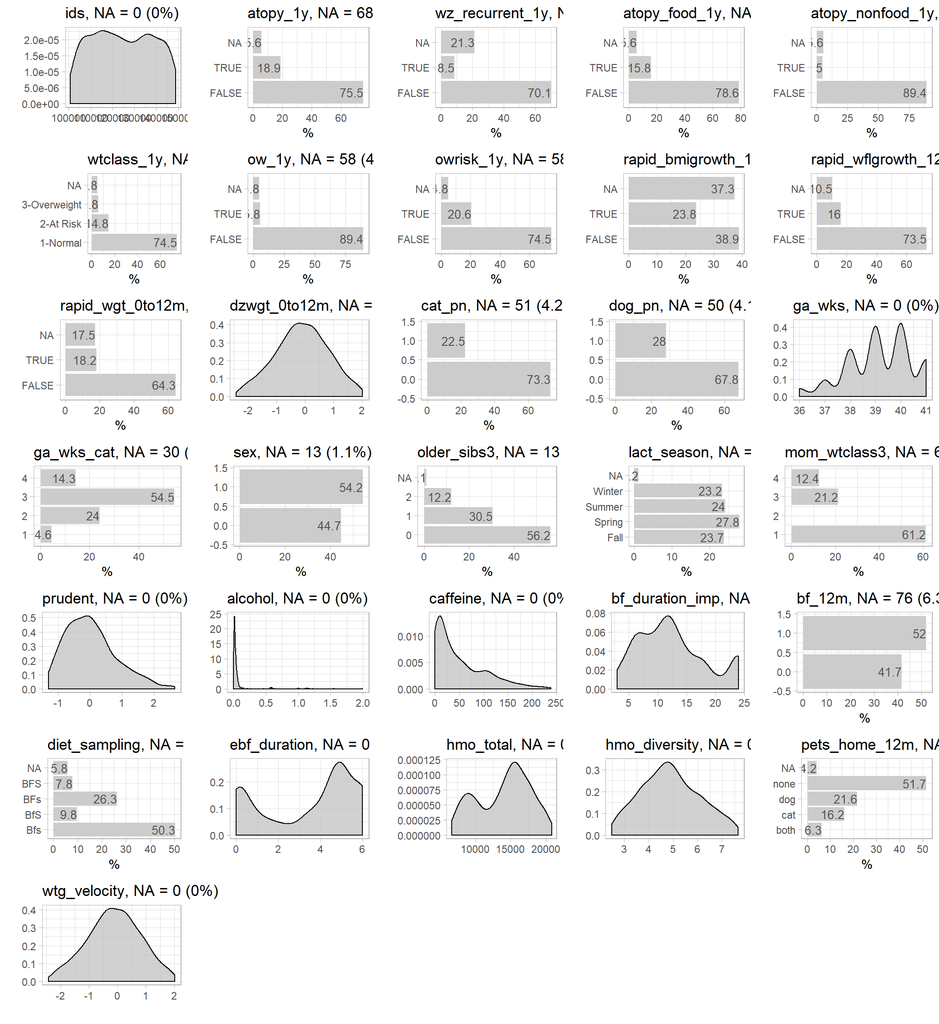

```r
ds %>% explore::explore_all(ncol = 5 )
```

## inspect-3 bivariate

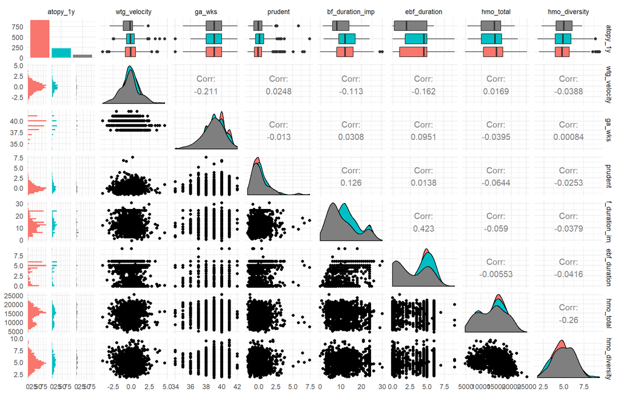

```r
# to view the outcomes against ONLY continuous variables
ds %>%
  dplyr::select_(.dots = c(
    "atopy_1y"         # outcome - Atopy at 1y (by SPT - reaction to any allergen)
    ,"wtg_velocity"    # outcome - Weight gain velocity from 0 to 12m (change in WHO weight z-score)
    ,"ga_wks"          # covar   - Gestational Age in weeks
    ,"prudent"         # covar   - Prudent Diet
    ,"bf_duration_imp" # feed    - Breastfeeding Duration in Months (implied)
    ,"ebf_duration"    # feed    - Duration of Exclusive Breastfeeding (Months)
    ,"hmo_total"       # milk    - Sum of all  HMOs
    ,"hmo_diversity"   # milk    - HMO Diversity
  )) %>%
  GGally::ggpairs(mapping = aes(fill = atopy_1y)) + theme_minimal()
```

# PHASE 1 - graph

## sketch the space

```r
# Let us sketch a graph that would map three dimensions:
# (x)     - horizontal - continuous
# (y)     - vertical   - continuous
# (color) - color      - discrete
```

## graph-1 basic

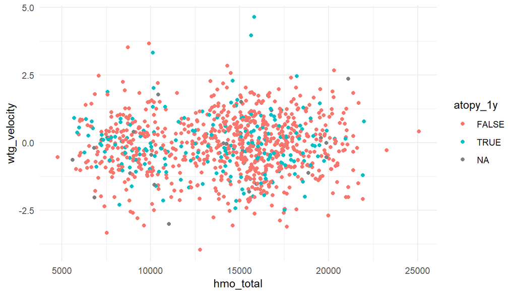

```r
# let us create a scatter plot between `hmo_total` and `wtg_velocity`,points colored by `atopy_1y`
# to create a ggplot2 object
g1 <- ds %>%
  # tidyr::drop_na(.dots = c("older_sibs3")) %>% # explore
  ggplot(
    aes(
      x      = hmo_total
      ,y     = wtg_velocity
      ,color = atopy_1y
    )
  ) +
  geom_point()+
  # facet_grid( pets_home_12m ~ older_sibs3 )+ # explore
  # facet_grid( pets_home_12m ~ older_sibs3 )+# explore
  theme_minimal()
g1
```

# PHASE 2 - make plot

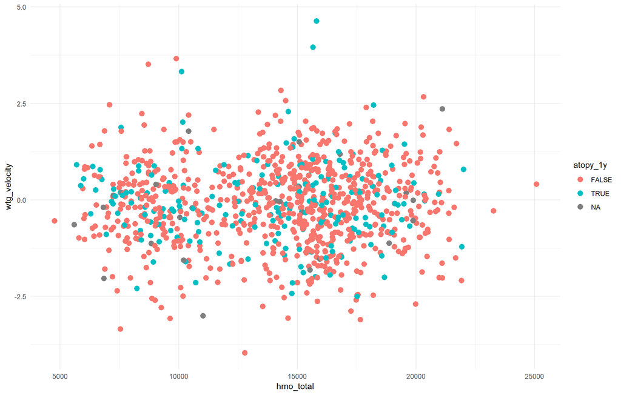

```r
# now let us re-express this plot as a custom function
# first, let us create a most basic function that takes no arguments and produces a graph
make_plot_1_basic <- function(
  d
){
  # d <- ds # for testing and development
  g_out <- d %>%
     ggplot(
      aes(
        x      = hmo_total
        ,y     = wtg_velocity
        ,color = atopy_1y
      )
    ) +
    geom_point(size = 3)+
    theme_minimal()
  return(g_out)
}
# how to use:
g <- ds %>%
  # tidyr::drop_na(.dots = c("older_sibs3")) %>%
  # dplyr::filter(older_sibs3 == 0) %>%
  # dplyr::filter(pets_home_12m == "none") %>%
  # notice that we keep some operations on the data outside of the function definition
  make_plot_1_basic()
g
```

```r
# g +  facet_grid( pets_home_12m ~ older_sibs3 )
```

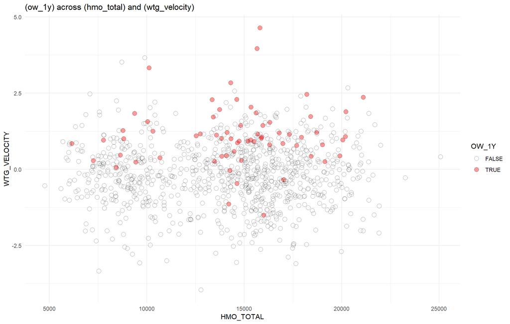

```r
# We need our function to offer us a convenient way to:
# 1. Control what variables are mapped onto the three dimensions we use
# 2. Control how color is mapped onto the level of the categorical variable

# if we were to pack everything into a single function we would get something like:
make_plot_1_packed <- function(
  d
  ,dim_horizontal
  ,dim_vertical
  ,dim_fill
  ,palette_custom = c("TRUE"="red", "FALSE"=NA)
){
  # to declare values for testing and development (within this function)
  # d <- ds
  # dim_horizontal = "hmo_total"
  # dim_vertical   = "wtg_velocity"
  # dim_fill      = "atopy_1y"
  # palette_custom = c("TRUE"="#1B9E77", "FALSE"="#D95F02")

  # data prep step
  d1 <- d %>%
    tidyr::drop_na(.dots = dim_fill) # to avoid clutter in labels
  custom_label_title = paste0(
    "(",dim_fill,") across (", dim_horizontal,") and (",dim_vertical,")"
  )
  custom_label_x     = toupper(dim_horizontal)
  custom_label_y     = toupper(dim_vertical)
  custom_label_fill  = toupper(dim_fill)

  # plotting prep step
  # palette_custom = c("TRUE"="#1B9E77", "FALSE"="#D95F02")

  # plotting step
  g_out <- d1 %>%
    ggplot(
      aes_string(
        x      = dim_horizontal # continuous  # hmo_total
        ,y     = dim_vertical   # continuous  # wtg_velocity
        ,fill  = dim_fill      # categorical # atopy_1y
        )
    ) +
    geom_point(shape = 21, alpha = .4, size= 3 )+
    scale_fill_manual(values = palette_custom)+
    theme_minimal()+
    labs(
      title  = custom_label_title
      ,x     = custom_label_x
      ,y     = custom_label_y
      ,fill  = custom_label_fill
    )
    # g_out # for viewing while developing
  return(g_out)
}
# how to use
g <- ds %>%
  make_plot_1_packed(
    dim_horizontal  = "hmo_total"
    ,dim_vertical   = "wtg_velocity"
    # ,dim_fill      = "atopy_1y"
    ,dim_fill       = "ow_1y"
  )# or:
# g <- ds %>% make_plot_1_packed("hmo_total","wtg_velocity","wz_recurrent_1y")
g
```

```r
# as you notice, the function got bulkier due to operations needed
# to construct a reference vector for factor levels
# these and other operations are typically best sourced out
# to the `prep_data` function
```

## applications

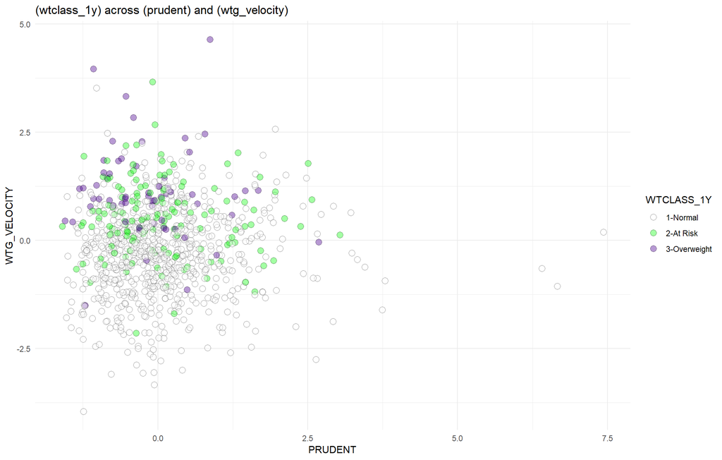

```r
# let us explore how we can use this function at this phase of development
g <- ds %>%
  make_plot_1_packed(
    # dim_horizontal  = "hmo_total"
    dim_horizontal  = "prudent"
    ,dim_vertical   = "wtg_velocity"
    # ,dim_vertical   = "ebf_duration"
    # ,dim_fill      = "atopy_1y"
    # ,dim_fill      = "wz_recurrent_1y"
    # ,dim_fill      = "rapid_wgt_0to12m"
    ,dim_fill       = "wtclass_1y" # Categorical with (3 levels)
    # ,dim_fill      = "wtg_velocity" # will produce error
    ,palette_custom = c("1-Normal" = "white", "2-At Risk" = "#1AFF1A", "3-Overweight" = "#4B0092")
    # palette from https://davidmathlogic.com/colorblind/#%231AFF1A-%234B0092
  )
g
```

```r
# g +  facet_grid( pets_home_12m ~ older_sibs3 )
```

# PHASE 3 - prep data

```r
# let us construct a new `prep_data` function that would
# isolate the preparatory operations from the `make_plot` function
prep_data_1 <- function(
  d
  ,dim_horizontal
  ,dim_vertical
  ,dim_fill
){
  # to declare values for testing and development (within this function)
  # d <- ds
  # dim_horizontal = "hmo_total"
  # dim_vertical   = "wtg_velocity"
  # dim_fill      = "atopy_1y"
  # palette_custom = c("TRUE"="#1B9E77", "FALSE"="#D95F02")

  # data prep step
  d1 <- d %>%
    tidyr::drop_na(.dots = dim_fill) # to avoid clutter in labels
  custom_label_title = paste0(
    "(",dim_fill,") across (", dim_horizontal,") and (",dim_vertical,")"
  )
  custom_label_x     = toupper(dim_horizontal)
  custom_label_y     = toupper(dim_vertical)
  custom_label_fill  = toupper(dim_fill)

  # to store objects for passing to the `make_plot` function
  l_support <- list()
  l_support[["data"]] <- d1
  l_support[["dimension"]] <- c(
    "horizontal" = dim_horizontal
    ,"vertical"  = dim_vertical
    ,"fill"      = dim_fill
  )
  l_support[["label"]] <- c(
     "x"      = custom_label_x
    ,"y"      = custom_label_y
    ,"fill"   = custom_label_fill
    ,"title"  = custom_label_title
  )

  lapply(l_support, class) # view contents
  # the make_plot funtion will rely on the structure and values in l_support

  return(l_support)
}
# how to use
l_support <- ds %>%
  prep_data_1(
    dim_horizontal  = "hmo_total"
    ,dim_vertical   = "wtg_velocity"
    ,dim_fill       = "atopy_1y"
    # ,dim_fill      = "wtclass_1y"
  )
l_support %>% print()
```

```
$data
# A tibble: 1,138 x 31
      ids atopy_1y wz_recurrent_1y atopy_food_1y
    <dbl> <lgl>    <lgl>           <lgl>
 1 141234 TRUE     FALSE           TRUE
 2 105842 TRUE     FALSE           TRUE
 3 114988 FALSE    FALSE           FALSE
 4 117827 TRUE     FALSE           TRUE
 5 148256 FALSE    FALSE           FALSE
 6 148374 FALSE    FALSE           FALSE
 7 126651 FALSE    FALSE           FALSE
 8 116605 FALSE    FALSE           FALSE
 9 132687 FALSE    FALSE           FALSE
10 130722 TRUE     FALSE           TRUE
# ... with 1,128 more rows, and 27 more variables:
#   atopy_nonfood_1y <lgl>, wtclass_1y <chr>,
#   ow_1y <lgl>, owrisk_1y <lgl>,
#   rapid_bmigrowth_12m <lgl>,
#   rapid_wflgrowth_12m <lgl>,
#   rapid_wgt_0to12m <lgl>, dzwgt_0to12m <dbl>,
#   cat_pn <dbl>, dog_pn <dbl>, ga_wks <dbl>,
#   ga_wks_cat <dbl>, sex <dbl>, older_sibs3 <chr>,
#   lact_season <chr>, mom_wtclass3 <dbl>,
#   prudent <dbl>, alcohol <dbl>, caffeine <dbl>,
#   bf_duration_imp <dbl>, bf_12m <dbl>,
#   diet_sampling <chr>, ebf_duration <dbl>,
#   hmo_total <dbl>, hmo_diversity <dbl>,
#   pets_home_12m <chr>, wtg_velocity <dbl>

$dimension
    horizontal       vertical           fill
   "hmo_total" "wtg_velocity"     "atopy_1y"

$label
                                                 x
                                       "HMO_TOTAL"
                                                 y
                                    "WTG_VELOCITY"
                                              fill
                                        "ATOPY_1Y"
                                             title
"(atopy_1y) across (hmo_total) and (wtg_velocity)"
```

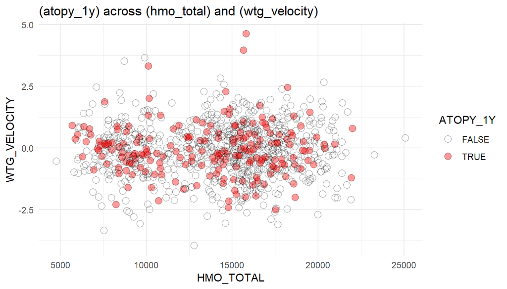

```r
# now we can pass this curated object `l_support` to graphing function
# note that we need to adjust the function to accomodate a new input object

make_plot_1 <- function(
  l_support
  ,palette_custom = c("TRUE"="red", "FALSE"=NA)
){
  # plotting prep step
  # palette_custom = c("TRUE"="#1B9E77", "FALSE"="#D95F02")

    # plotting step
  g_out <- l_support[["data"]] %>%
    ggplot(
      aes_string(
        x      = l_support[["dimension"]]["horizontal"] # continuous  # hmo_total
        ,y     = l_support[["dimension"]]["vertical"]   # continuous  # wtg_velocity
        ,fill = l_support[["dimension"]]["fill"]      # categorical # atopy_1y
      )
    ) +
    geom_point(shape = 21, alpha = .4, size= 3 )+
    scale_fill_manual(values = palette_custom)+
    theme_minimal()+
    labs(
      title  = l_support[["label"]]["title"]
      ,x     = l_support[["label"]]["x"]
      ,y     = l_support[["label"]]["y"]
      ,fill = l_support[["label"]]["fill"]
    )
  # g_out # for viewing while developing
  l_support[["graph"]]   <- g_out
  return(l_support)
}
# how to use
# to add a new element in `l_support`` that would contain the plot
l_support <- ds %>%
  prep_data_1(
    dim_horizontal  = "hmo_total"
    ,dim_vertical   = "wtg_velocity"
    ,dim_fill       = "atopy_1y"
    # ,dim_fill      = "wz_recurrent_1y"
  ) %>%
  make_plot_1()
l_support$graph %>% print() # note that printing is a separate step
```

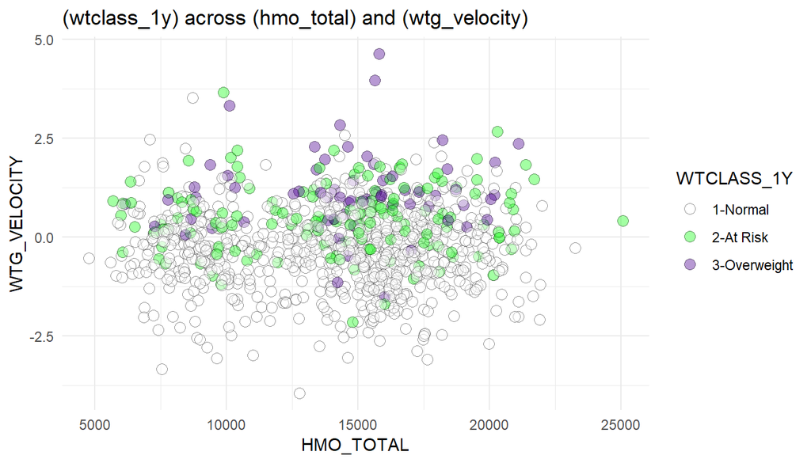

```r
# applications:
l_support <- ds %>%
  prep_data_1(
    dim_horizontal  = "hmo_total"
    ,dim_vertical   = "wtg_velocity"
    # ,dim_fill      = "atopy_1y"
    # ,dim_fill      = "rapid_wgt_0to12m"
    ,dim_fill       = "wtclass_1y"
    # ,dim_fill      = "wtg_velocity" # will produce error
  ) %>%
  make_plot_1(
    palette_custom = c("1-Normal" = "white", "2-At Risk" = "#1AFF1A", "3-Overweight" = "#4B0092")
    # palette from https://davidmathlogic.com/colorblind/#%231AFF1A-%234B0092
  )
l_support$graph %>% print()
```

# PHASE 4 - print plot

```r
# Now we need a function that would help up control the printing parameters
print_plot_1 <- function(
  l_support
  ,path_output_folder
  ,prefex             = NA      # string token to mark the version
  ,graph_name         = "auto"  # replace with custom name
  ,...
){
  # path_output_folder = "./analysis/prep-plot-print/demo-1/"
  # prefex            = "attempt1"

  file_name = paste0("("
    ,l_support$dimension["color"]
    ,")-across-("
    , l_support$dimension["horizontal"]
    ,")-and-("
    ,l_support$dimension["vertical"]
    ,")"
  )
  if( !graph_name == "auto" ){ # to trigger auto, must be `auto`
    (file_name <- graph_name) # replace with a custom string
  }
  # add a label to distinguish a particular graph (first element in the file name)
  if( !is.na(prefex) ){ # inserts a PREFEX before the graph name
    (path_save_plot <- paste0(path_output_folder, prefex,"-",file_name) )
  }else{
    ( path_save_plot <- paste0(path_output_folder, file_name) )
  }
  # if folder does not exist yet, create it
  if( !dir.exists(path_output_folder) ){
    dir.create(path_output_folder)
  }
  # print the graphical object using jpeg device
  path_printed_plot <- paste0(path_save_plot, ".jpg")
  jpeg(
    filename = path_printed_plot
    ,...
  )
  l_support$graph %>% print() # reach into the custom object we made for plotting
  dev.off() # close the device
  l_support[["path_plot"]] <- path_printed_plot # save the path where plot was printed
  return(l_support)
}
# how to use
l_support <- ds %>%
  prep_data_1(
    dim_horizontal  = "hmo_total"
    ,dim_vertical   = "wtg_velocity"
    ,dim_fill      = "atopy_1y"
  ) %>%
  make_plot_1() %>%
  print_plot_1(
    path_output_folder = "./analysis/prep-plot-print/demo-1-print/"
    ,prefex            = "1600-900"
    # ,graph_name        = "take1" # `auto` by default
# options added through `...` into the jpeg() function
    ,width   = 1600
    ,height  = 900
    ,units   = "px" # "px" - pixels,  "in" - inches , "cm" - centimiters
    ,quality = 100  # percent
    ,res     = 200  # resolution, dots per inch
    # ,res     = 100
  )
```

To remind us of the dimensions in typical formats:

```r
# canvas size guide ( portrait orientation )

# Size           Width x Height (mm) Width x Height (in)  Aspect Ratio
# Half Letter      140 x 216           5.5 x  8.5          1: 1.55
# Letter           216 x 279           8.5 x 11.0          1: 1.29
# Legal            216 x 356           8.5 x 14.0          1: 1.65
# Junior Legal     127 x 203           5.0 x  8.0          1: 1.60
# Ledger/Tabloid   279 x 432          11.0 x 17.0          1: 1.55
```

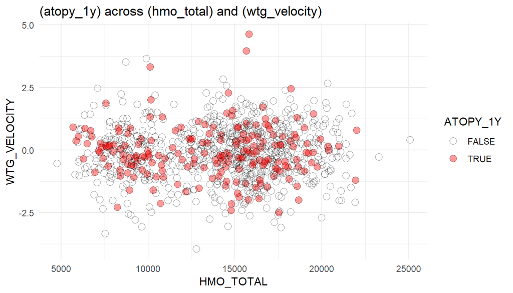

```r
# notice that if I print the GRAPH by reaching into the `l_support` object
# if will be displayed according to the `fig.width`, `fig.height`, and `out.width`
# parameters specified in the chuck options (in the .Rmd file)
l_support$graph %>% print()
```

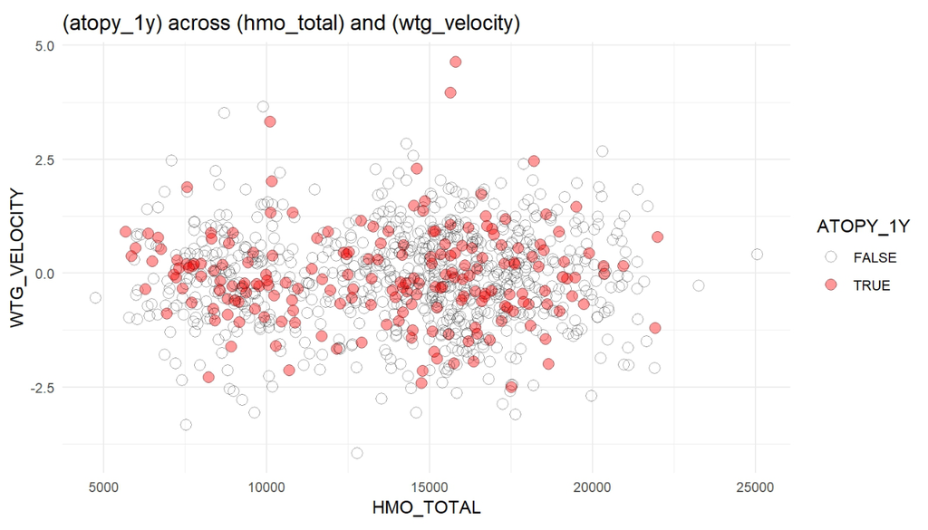

```r
# if, however, we reach into the disk, we will recover the image generated
# with the dimensions and specs defined in the `print_plot` function
l_support$path_plot %>% jpeg::readJPEG() %>% grid::grid.raster()
```

```r
# this is where savingt he path to the printed object comes handy
```

# PHASE 5 - serialize

```r
# it often makes sense to genrate a series of plot to be explored manually

# GRAPH SERIES A
outcomes_binary <- c(
     "atopy_1y"            # (Bin)  Atopy at 1y (by SPT - reaction to any allergen)
    ,"wz_recurrent_1y"     # (Bin)  Recurrent wheeze at 1y: 2+ episodes (ZL 06-2015)    Binary
    ,"atopy_food_1y"       # (Bin)  Sensitization to food allergen at 1y by SPT Binary
    ,"atopy_nonfood_1y"    # (Bin)  Sensitization to non-food allergen at 1y by SPT Binary
    # ,"wtclass_1y"          # (Cat3) Weight Class at 1y (based on WFL z-score) Categorical
    ,"ow_1y"               # (Bin)  Overweight at 1y (WFL z-score > 97%ile) Binary
    ,"owrisk_1y"           # (Bin)  At risk for overweight at 1y (WFL z-score > 85%ile) Binary
    ,"rapid_bmigrowth_12m" # (Bin)  >1 SD change in z-score from birth(BMI) to 12m(BMI) Binary
    ,"rapid_wflgrowth_12m" # (Bin)  >1 SD change in z-score from birth(WFA) to 12m(WFL) Binary
    ,"rapid_wgt_0to12m"    # (Bin)  Change in WHO zwgt >0.67    Binary
    # ,"dzwgt_0to12m"        # (Num)  Weight gain velocity from 0 to 12m (change in WHO weight z-score)
  )
# for each selected outcome create plot_1 in this folder
path_target_series_A <- "./analysis/prep-plot-print/demo-2-series-A/" # where images will be printed
ls_plot_series <- list() # to capture the collection of graphs and their file paths
for(outcome_i in outcomes_binary){
  ls_plot_series[[outcome_i]]  <- ds %>%
    prep_data_1(
      dim_horizontal  = "hmo_total"
      ,dim_vertical   = "wtg_velocity"
      ,dim_fill      = outcome_i
    ) %>%
    make_plot_1() %>%
    print_plot_1(
      path_output_folder = path_target_series_A #  where images will be printed
      # ,prefex            = "1600-900"
      # ,graph_name        = "take1" # `auto` by default
      # options added through `...` into the jpeg() function
      ,width   = 1600
      ,height  = 900
      ,units   = "px" # "px" - pixels,  "in" - inches , "cm" - centimiters
      ,quality = 100  # percent
      ,res     = 200  # resolution, dots per inch
    )
}
saveRDS(ls_plot_series, paste0(path_target_series_A,"ls_plots.rds") )
```

```r
# GRAPH SERIES B
# for each selected outcome create plot_1 in this folder
path_target_series_B <- "./analysis/prep-plot-print/demo-2-series-B/" # where images will be printed
ls_plot_series <- list() # to capture the collection of graphs and their file paths
for(outcome_i in outcomes_binary){
  ls_plot_series[[outcome_i]]  <- ds %>%
    prep_data_1(
      dim_horizontal  = "hmo_total"
      ,dim_vertical   = "caffeine"
      ,dim_fill      = outcome_i
    ) %>%
    make_plot_1() %>%
    print_plot_1(
      path_output_folder = path_target_series_B #  where images will be printed
      # ,prefex            = "1600-900"
      # ,graph_name        = "take1" # `auto` by default
      # options added through `...` into the jpeg() function
      ,width   = 1600
      ,height  = 900
      ,units   = "px" # "px" - pixels,  "in" - inches , "cm" - centimiters
      ,quality = 100  # percent
      ,res     = 200  # resolution, dots per inch
    )
}
saveRDS(ls_plot_series, paste0(path_target_series_B,"ls_plots.rds") )
```

# PHASE 6 - place plot

```r
ls_plot_series <- readRDS("./analysis/prep-plot-print/demo-2-series-B/ls_plots.rds")
ls_plot_series[["atopy_1y"]]$path_plot
```

```
[1] "./analysis/prep-plot-print/demo-2-series-B/(NA)-across-(hmo_total)-and-(caffeine).jpg"
```

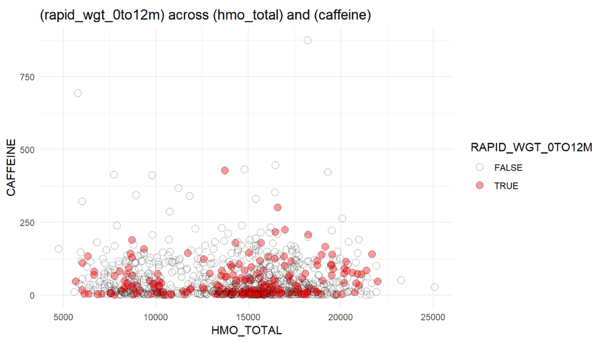

```r
ls_plot_series[["atopy_1y"]]$path_plot %>% jpeg::readJPEG() %>% grid::grid.raster()
```

# future direction

- Integrate the choice of transperancy into function arguments
- Wrapper function to streamline looping through outcomes
- Incorporate faceting (wrap, grid) into the function sequence
- Automate the choice of palette for any number of colors

# session information

For the sake of documentation and reproducibility, the current report was rendered in the following environment. Click the line below to expand.

Report rendered by an499583 at 2019-06-12, 05:12 -0700 in 65 seconds.